# lab3_assembly_annotation

## Question 1:

Assembly statistics:

```
    Total length:   12760092
    Fragments:      357
    Fragments N50:  52735
    Largest frg:    302365
    Scaffolds:      0
    Mean coverage:  8
```

The quality of this genome assembly is low and is incomplete for two main reasons. Firstly, the assembly is highly fragmented. Being broken into 357 separate pieces means we have many small segments of the genetic code, but we don’t know their correct order or what information is missing in the gaps between them. Second, this fragmentation is a direct result of the very low sequencing coverage, which is only 8x. Reading each position in the genome only 8 times is not enough to build confidence. This lack of data forced the assembly software to stop and leave the genome in hundreds of disconnected pieces, making it unreliable and incomplete.

## Question 2:

```bash
# had to adjust the code to take it fun within my directory
docker run --rm \
  -v "$PWD":/data \
  -w /data \
  ezlabgva/busco:v6.0.0_cv1 \
  busco -i flye_output/assembly.fasta -o busco_output -l saccharomycetaceae_odb12 -m genome -c 8 -f
```

Results from dataset saccharomycetaceae_odb12

```
C:33.7%[S:33.6%,D:0.1%],F:0.4%,M:65.9%,n:3282,E:5.2%
1106    Complete BUSCOs (C) (of which 59 contain internal stop codons)
1102    Complete and single-copy BUSCOs (S)
4   Complete and duplicated BUSCOs (D)
14  Fragmented BUSCOs (F)
2162    Missing BUSCOs (M)
3282    Total BUSCO groups searched
```

Assembly Statistics:

```
357 Number of scaffolds
357 Number of contigs
12760092    Total length
0.000%  Percent gaps
52 kbp  Scaffold N50
52 kbp  Contigs N50
```

The final genome assembly had a total length of 12,760,092 bp but the analysis of the quality showed some significant issues. The BUSCO assessment showed the assembly was highly incomplete, with only 33.7% of expected core genes found completely and 65.9% classified as missing. This poor result is a direct reflection of the inadequate 8x sequencing coverage, which provided insufficient data for the Flye assembler to reconstruct the full genome. Further characterization of the assembly’s continuity showed a contig N50 of 52 kbp, a value consistent with the 52,735 bp originally calculated by Flye which is reconfirming a fragmented result.

## Question 3

```bash
docker run --rm -v "$(pwd)":/data -w /data quay.io/biocontainers/quast:5.3.0--py313pl5321h5ca1c30_2 \
  quast.py flye_output/assembly.fasta \
  -r GCF_000146045.2_R64_genomic.fna \
  -g GCF_000146045.2_R64_genomic.gff \
  -o quast_output
```

All statistics are based on contigs of size >= 500 bp, unless otherwise noted (e.g., “# contigs (>= 0 bp)” and “Total length (>= 0 bp)” include all contigs).

```
Assembly                     assembly
# contigs (>= 0 bp)          357
# contigs (>= 1000 bp)       357
# contigs (>= 5000 bp)       357
# contigs (>= 10000 bp)      327
# contigs (>= 25000 bp)      163
# contigs (>= 50000 bp)      76
Total length (>= 0 bp)       12760092
Total length (>= 1000 bp)    12760092
Total length (>= 5000 bp)    12760092
Total length (>= 10000 bp)   12503560
Total length (>= 25000 bp)   9773450
Total length (>= 50000 bp)   6666774
# contigs                    357
Largest contig               302365
Total length                 12760092
Reference length             12157105
GC (%)                       42.01
Reference GC (%)             38.15
N50                          52735
NG50                         53735
N90                          16257
NG90                         18742
auN                          69436.1
auNG                         72880.1
L50                          71
LG50                         65
L90                          249
LG90                         218
# misassemblies              0
# misassembled contigs       0
Misassembled contigs length  0
# local misassemblies        1
# scaffold gap ext. mis.     0
# scaffold gap loc. mis.     0
# unaligned mis. contigs     3
# unaligned contigs          334 + 23 part
Unaligned length             12693618
Genome fraction (%)          0.530
Duplication ratio            1.157
```

[output cut: 23 more lines]

```
NG50    53735
NG90    18742
auNG    72880
NA50    -
NA90    -
auNA    125.8
NGA50   -
NGA90   -
auNGA   132.1
LG50    65
LG90    218
LA50    -
LA90    -
LGA50   -
LGA90   -
```

1. The Genome Fraction was 0.53%. This is extremely low is different with the BUSCO completeness score of 33.7%. This variation shows that while the BUSCO analysis could identify about a third of the expected core genes, less than 1% of the entire assembly could be aligned to the provided reference genome. This could show the sequenced strain genetic variance making a direct comparison difficult.
2. The Duplication Ratio was 1.157. This value is relatively close to the ideal of 1.0, indicating that large-scale duplications are not a significant issue in the assembled contigs.
3. The report shows 0 misassemblies and a Misassembled contigs length of 0. That seems positive but it can be a consequence of low genome fraction. Since only a tiny fraction of the assembly could be aligned, there was little data to check for errors. This suggests that the chosen reference genome does not represent the genomic diversity of the sequenced S. cerevisiae strain; the two are soo divergent that most of the assembly could not be compared making it hard to assess for misassemblies across the whole genome.

## Question 4

```r
library(Biostrings)
genome <- readDNAStringSet("GCF_000146045.2_R64_genomic.fna")
chr1 <- genome[grep("chromosome I", names(genome), ignore.case = TRUE)]
writeXStringSet(chr1, "R64_chr1.fna")
```

## Question 5

There were 2 contigs aligned to the chromosome.

```r
library(Rsamtools)
library(GenomicAlignments)
```

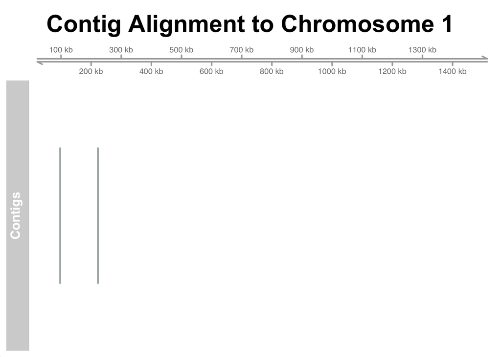

```r
library(GenomicRanges)
library(Gviz)
bam_file <- "alignment.sorted.bam"
bam <- BamFile(bam_file)

alns <- readGAlignments(bam)
options(ucscChromosomeNames = FALSE)

gr_alns <- granges(alns)
aln_track <- AnnotationTrack(gr_alns, name = "Contigs", genome = "sacCer3", chromosome = "NC_001133.9")


axis_track <- GenomeAxisTrack()
# Plot
plotTracks(list(axis_track, aln_track),
           from = min(start(gr_alns)),
           to = max(end(gr_alns)),
           main = "Contig Alignment to Chromosome 1")
```

## Question 6

```r
assembly <- readDNAStringSet("flye_output/assembly.fasta")
lengths <- width(assembly)
longest_contig <- assembly[which.max(lengths)]
writeXStringSet(longest_contig, "longest_contig.fasta")
```

## Question 7

```bash
# 1. Convert the SAM file to a compressed BAM file
samtools view -bS contig_aln.sam > contig_aln.bam

# 2. Sort the BAM file by genomic coordinates
samtools sort contig_aln.bam -o contig_aln.sorted.bam

# 3. Create an index for the sorted BAM file
samtools index contig_aln.sorted.bam
```

## Question 8

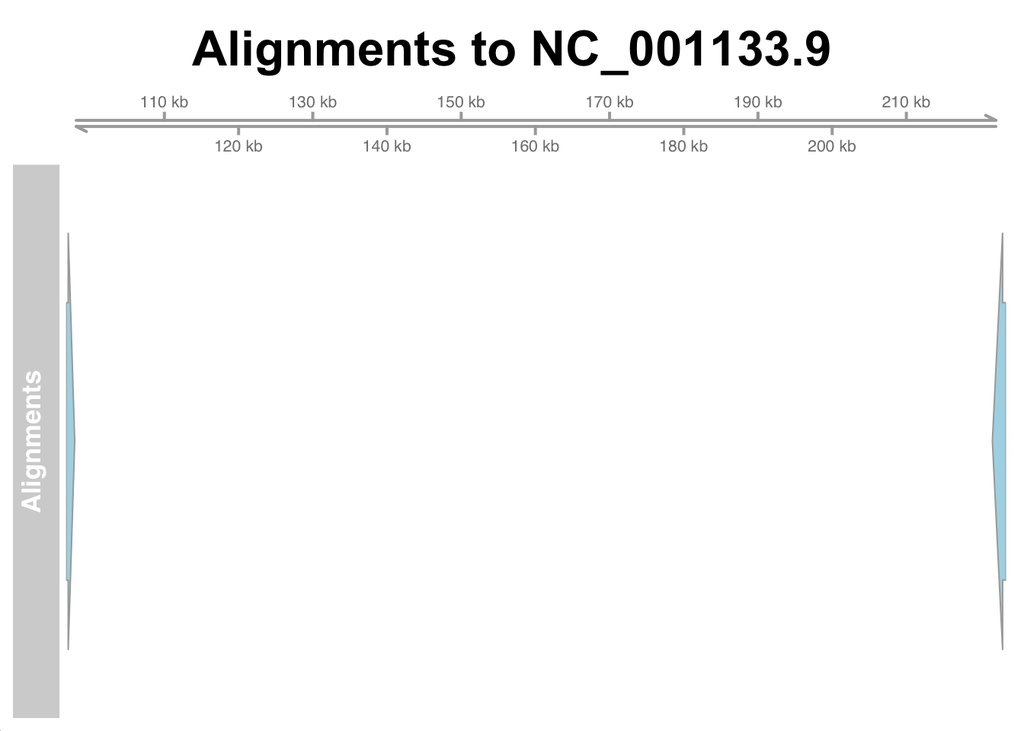

```r
# Load your full alignment data
bam_file <- "contig_aln.sorted.bam"
alns <- readGAlignments(bam_file)
gr_alns <- granges(alns)

# --- Add this missing filter step ---
# 1. Choose a valid chromosome to plot
target_chr <- "NC_001133.9" # Or another valid chromosome name

# 2. Filter the data to create the 'gr_alns_filtered' object
gr_alns_filtered <- gr_alns[seqnames(gr_alns) == target_chr]


# --- Now the rest of your plotting code will work ---
# Create Gviz tracks
aln_track <- AnnotationTrack(gr_alns_filtered, name = "Alignments")
axis_track <- GenomeAxisTrack()

# Plot the tracks
plotTracks(list(axis_track, aln_track),
           from = min(start(gr_alns_filtered)), # This will now find the object
           to = max(end(gr_alns_filtered)),   # This will also find the object
           main = paste("Alignments to", target_chr))
```